# part_1

```
Linux-6.18.33.2-microsoft-standard-WSL2-x86_64-with-glibc2.43 | torch 2.0.0+cu117 | numpy 1.23.5
```

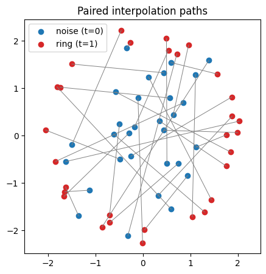

**Task 1.** Source points come from a standard 2D Gaussian N(0, I). The target is a ring of radius 2: angle uniform in [0, 2π), radius = 2 + 0.1 × Gaussian noise. Both use the same coordinate scale (most noise points fall within ±3). Each noise point is randomly paired with a ring point, and t is drawn uniformly from [0, 1]. The velocity along each training path is constant because the path is a straight line travelled at constant speed: x_t = x0 + t(x1 − x0), so the change per unit time is always x1 − x0, no matter what t is.

```
step 5000: loss 3.871
step 10000: loss 3.847
step 15000: loss 3.871
step 20000: loss 3.849
step 25000: loss 3.844
step 30000: loss 3.841
Training time: 30.9 s
Parameters: 33794
```

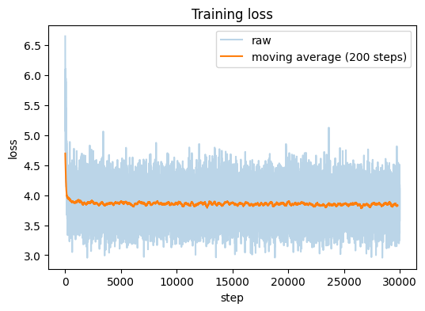

**Task 2.** The network receives only the current position x_t and time t, and predicts the velocity x1 − x0. It never sees the start or end point. Because pairs are random, many pairs pass through the same position and time with different velocities, so the best the network can do is predict their average. That's why the loss levels off (about 3.84) instead of going to zero.

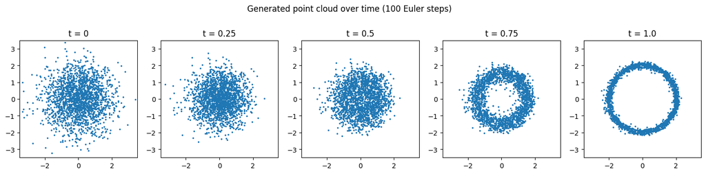

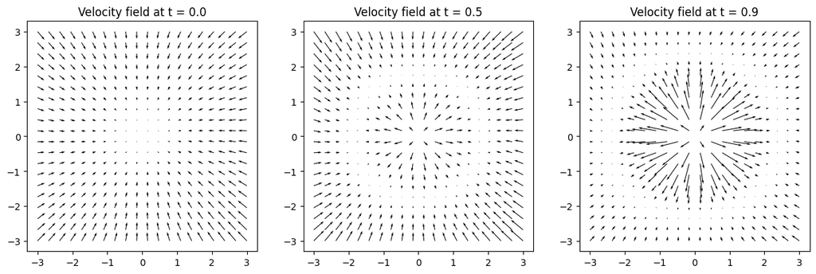

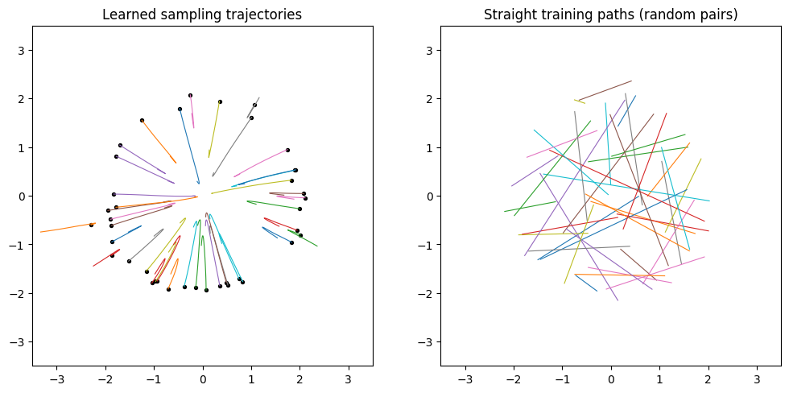

**Task 3.** Generation starts from fresh Gaussian noise with no endpoints given, and follows the learned velocity for 100 Euler steps. The training paths are straight and cross each other. The learned paths are curved and don't cross, because the model gives only one velocity per position and time: it follows the average of many crossing training lines, and that average changes direction as the point moves. Straight training paths do not guarantee straight sampling paths.

```
CPU: 13th Gen Intel(R) Core(TM) i7-1355U
OS: Linux-6.18.33.2-microsoft-standard-WSL2-x86_64-with-glibc2.43
Threads used: 2 | GPU: none (CPU only)
Python 3.9.25 | torch 2.0.0+cu117 | numpy 1.23.5 | matplotlib 3.7.2
```